# Hoxell-enabled Personalization: Berna Hotel

Gabriele Piccoli

# Mac OS X: TexLive 2013 (Full) - http://tug.org/mactex/

# (NOTE: Download with Safari rather than Chrome *strongly* recommended)

# Introduction

This is the current report for the persalization study of *HGRM* use at the *Berna Hotel*. The report was generated on 22 October, 2015.

# Basic statistics

The dataset includes **105087** reservations for **108245** hotel stays during the **01 January, 2010** to **03 July, 2015** timeframe. Of these, **14658** are personalized either physically or through myPage.

## Personalization Request via Traditional Channel and myPage

```
##             mean     sd min  max
## Stays    1640.08 232.09 808 2167
## physical   35.03  19.27   2  100
## virtual   232.28  60.06 102  374
## physical    1.06   0.26   1    4
## virtual     5.99   3.30   1   32
```

# The effect of Hoxell on preference elicitation: Customers

Our analysis shows that the introduction of Hoxell has a significant impact on the number of guests who personalize their stay at Berna Hotel. It also indicates that the introduciton of personalization featurs in Hoxell has a positive effect on personalization via the tradition (physical) method.

## Poisson and Binomial Regression Results

```
##                    Estimate Std. Error z value Pr(>|z|)
## (Intercept)            0.06       0.02    2.77     0.01   NA
## Methodvirtual          1.73       0.02   84.99     0.00   NA
## (Intercept)           -4.11       0.06  -74.37     0.00 0.02
## methodvirtual          1.97       0.02   80.38     0.00 7.18
## virtualizationTRUE     0.36       0.06    6.08     0.00 1.44
```

–

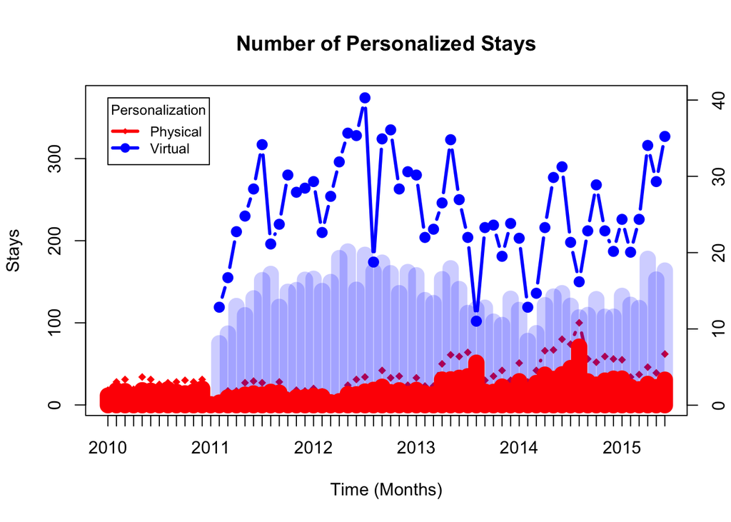

# The effect of Hoxell on preference elicitation: Personalizations

This analysis focuses on the number of itmes requested by customers who personalize. We find a strong impact of Hoxell on the number of items requested by customers. Specifically when personalizing through traditional means customers chose an average of 1.06 items. Conversely, when using Hoxell they select 5.99 items.

–

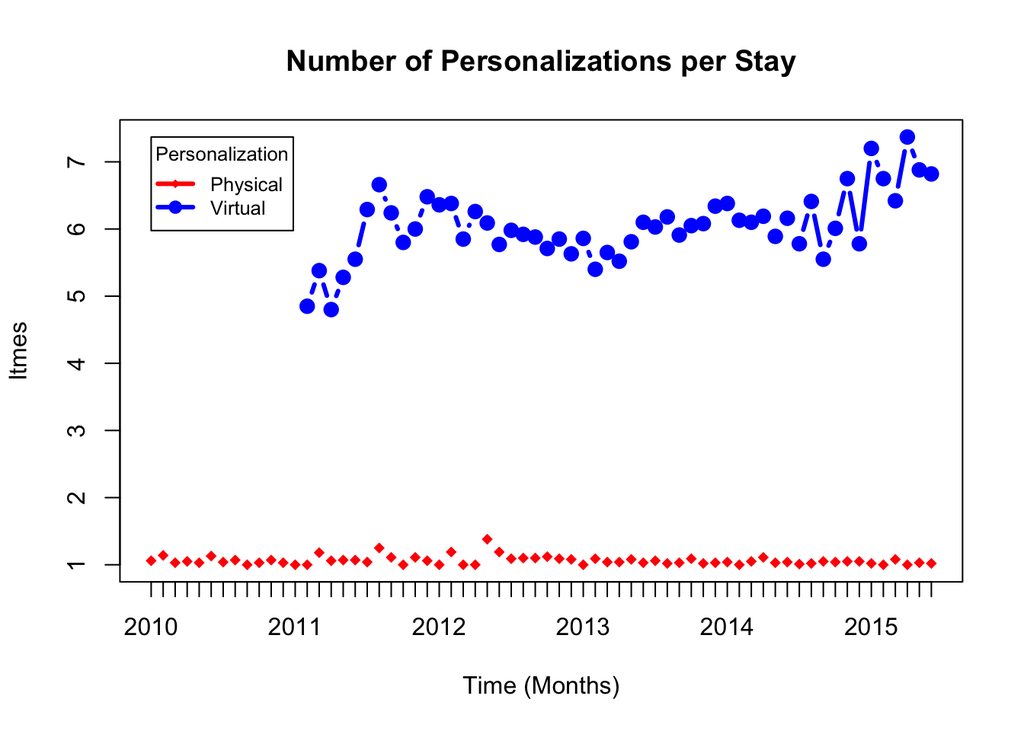

# Analysis of emails

Ths section provides a monthly analysis of emails sent via the Mandrill application.

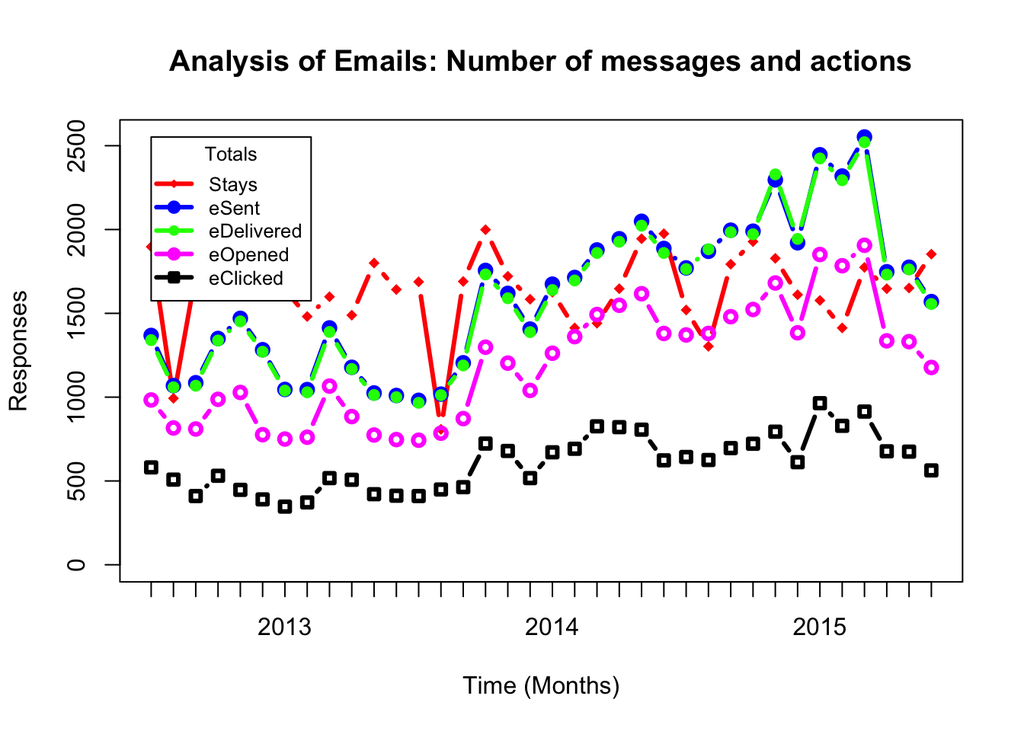

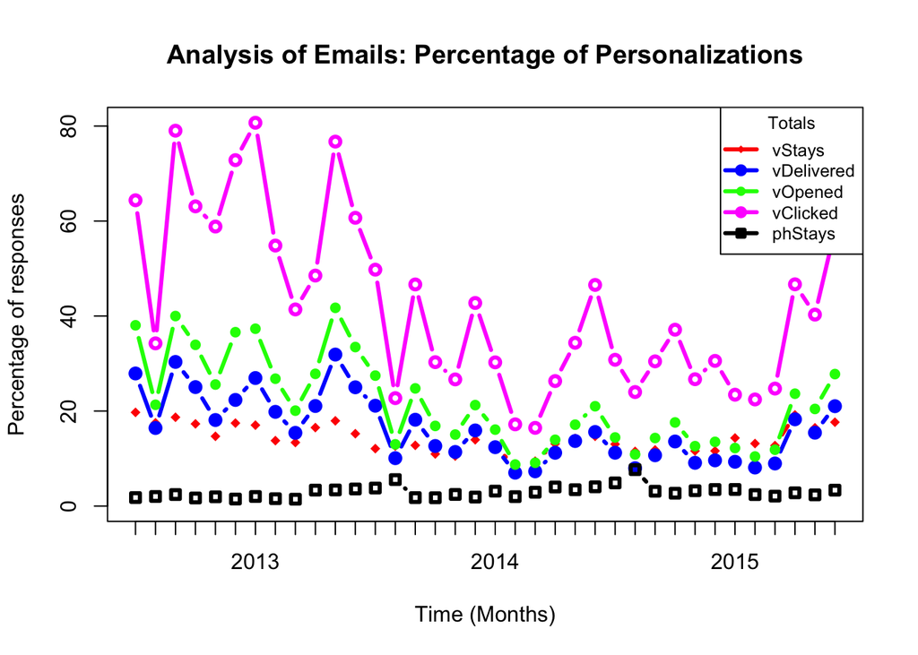

# The Effect of Personalization on Service and Value Hotel Ratings

We test the effect of personalizations on hotel service and value ratings using 5406 reviews posted to Booking.com merged with reservation data.

## Personalization Effect on Service

```
##                          Estimate Std. Error z value Pr(>|z|)
## 2.5|5                      -4.446      0.224 -19.875    0.000    NA
## 5|7.5                      -2.425      0.166 -14.637    0.000    NA
## 7.5|10                      0.071      0.157   0.454    0.650    NA
## Personalization             0.176      0.067   2.628    0.009 1.192
## ADR                        -0.183      0.034  -5.425    0.000 0.832
## LoS                         0.021      0.022   0.935    0.350 1.021
## ROOM_TYPEQUALITY            0.187      0.086   2.180    0.029 1.206
## ROOM_TYPESUPERIOR           0.336      0.104   3.245    0.001 1.400
## ROOM_TYPESINGOLA (BASIC)   -0.026      0.097  -0.273    0.785 0.974
## ADULTS                      0.201      0.078   2.572    0.010 1.223
## CHILDREN                    0.169      0.114   1.487    0.137 1.184
## PrefPrice                  -0.007      0.011  -0.654    0.513 0.993
```

## Personalization Effect on Value

```
##                          Estimate Std. Error z value Pr(>|z|)
## 2.5|5                      -3.430      0.180 -19.109    0.000    NA
## 5|7.5                      -1.598      0.153 -10.418    0.000    NA
## 7.5|10                      0.578      0.151   3.834    0.000    NA
## Personalization             0.178      0.064   2.778    0.005 1.194
## ADR                        -0.381      0.033 -11.400    0.000 0.683
## LoS                        -0.037      0.021  -1.799    0.072 0.964
## ROOM_TYPEQUALITY            0.250      0.082   3.041    0.002 1.284
## ROOM_TYPESUPERIOR           0.354      0.098   3.600    0.000 1.425
## ROOM_TYPESINGOLA (BASIC)    0.096      0.094   1.022    0.307 1.101
## ADULTS                      0.335      0.075   4.483    0.000 1.398
## CHILDREN                    0.016      0.106   0.152    0.880 1.016
## PrefPrice                  -0.005      0.010  -0.504    0.614 0.995
```

## The Effect of Number of Personalization on Service

```
##                                     Estimate Std. Error z value Pr(>|z|)
## 2.5|5                                 -4.362      0.487  -8.962    0.000
## 5|7.5                                 -2.416      0.362  -6.683    0.000
## 7.5|10                                 0.195      0.342   0.572    0.568
## Count.of.Personalization.Items.Used    0.034      0.018   1.903    0.057
## ADR                                   -0.137      0.073  -1.870    0.061
## LoS                                    0.002      0.044   0.055    0.956
## ROOM_TYPEQUALITY                       0.012      0.165   0.070    0.944
## ROOM_TYPESUPERIOR                      0.281      0.210   1.339    0.181
## ROOM_TYPESINGOLA (BASIC)               0.284      0.210   1.355    0.175
## ADULTS                                 0.257      0.166   1.551    0.121
## CHILDREN                               0.686      0.303   2.260    0.024
## PrefPrice                             -0.011      0.011  -0.996    0.319
##
## 2.5|5                                  NA
## 5|7.5                                  NA
## 7.5|10                                 NA
## Count.of.Personalization.Items.Used 1.035
## ADR                                 0.872
## LoS                                 1.002
## ROOM_TYPEQUALITY                    1.012
## ROOM_TYPESUPERIOR                   1.325
## ROOM_TYPESINGOLA (BASIC)            1.329
## ADULTS                              1.293
## CHILDREN                            1.986
## PrefPrice                           0.989
```

## The Effect of Number of Personalization on Value

```
##                                     Estimate Std. Error z value Pr(>|z|)
## 2.5|5                                 -3.919      0.423  -9.259    0.000
## 5|7.5                                 -1.807      0.336  -5.382    0.000
## 7.5|10                                 0.542      0.328   1.654    0.098
## Count.of.Personalization.Items.Used    0.016      0.017   0.952    0.341
## ADR                                   -0.335      0.074  -4.531    0.000
## LoS                                   -0.081      0.041  -1.973    0.049
## ROOM_TYPEQUALITY                       0.200      0.160   1.254    0.210
## ROOM_TYPESUPERIOR                      0.293      0.198   1.476    0.140
## ROOM_TYPESINGOLA (BASIC)               0.228      0.201   1.131    0.258
## ADULTS                                 0.394      0.158   2.500    0.012
## CHILDREN                               0.256      0.241   1.062    0.288
## PrefPrice                             -0.007      0.011  -0.625    0.532
##
## 2.5|5                                  NA
## 5|7.5                                  NA
## 7.5|10                                 NA
## Count.of.Personalization.Items.Used 1.016
## ADR                                 0.715
## LoS                                 0.922
## ROOM_TYPEQUALITY                    1.222
## ROOM_TYPESUPERIOR                   1.340
## ROOM_TYPESINGOLA (BASIC)            1.256
## ADULTS                              1.483
## CHILDREN                            1.292
## PrefPrice                           0.993
```

# Hoxell Impact on Positive Share-Shift

This analysis focuses on the effect of personalization on the creation of a direct relationship with the customers that leads to share-shift from intermediated (high-cost) to direct (low-cost) distribution channels.

The analysis is based on a sample of 8393 reservations by guests who visited the hotel more than once during the timeframe of our analysis. Of these returning customers 1535 engaged in personalization during their first visit to the Berna Hotel.

## Beneficial Share-Shift

```
##                              Estimate Std. Error z value Pr(>|z|)
## (Intercept)                    -1.300      0.196  -6.617    0.000
## I(Method.0 == "Virtual")TRUE    0.250      0.106   2.361    0.018
## ADR.1                           0.015      0.049   0.299    0.765
## ROOM_TYPE.1QUALITY              0.504      0.142   3.547    0.000
## ROOM_TYPE.1SUPERIOR             0.416      0.143   2.906    0.004
## ROOM_TYPE.1SINGOLA (BASIC)      0.117      0.124   0.944    0.345
## ADULTS.1                       -0.379      0.108  -3.512    0.000
## CHILDREN.1                     -0.255      0.200  -1.276    0.202
##                              Odds.Ratio
## (Intercept)                       0.273
## I(Method.0 == "Virtual")TRUE      1.284
## ADR.1                             1.015
## ROOM_TYPE.1QUALITY                1.655
## ROOM_TYPE.1SUPERIOR               1.515
## ROOM_TYPE.1SINGOLA (BASIC)        1.125
## ADULTS.1                          0.684
## CHILDREN.1                        0.775
## [1] 0.1774295
```

## Detrimental Share-Shift

```
##                              Estimate Std. Error z value Pr(>|z|)
## (Intercept)                    -1.103      0.279  -3.947    0.000
## I(Method.0 == "Virtual")TRUE   -0.566      0.146  -3.865    0.000
## ADR.1                           0.145      0.069   2.105    0.035
## ROOM_TYPE.1QUALITY             -0.642      0.236  -2.720    0.007
## ROOM_TYPE.1SUPERIOR            -0.607      0.200  -3.037    0.002
## ROOM_TYPE.1SINGOLA (BASIC)      0.420      0.172   2.443    0.015
## ADULTS.1                       -0.018      0.161  -0.110    0.913
## CHILDREN.1                      0.161      0.248   0.648    0.517
##                              Odds.Ratio
## (Intercept)                       0.332
## I(Method.0 == "Virtual")TRUE      0.568
## ADR.1                             1.156
## ROOM_TYPE.1QUALITY                0.526
## ROOM_TYPE.1SUPERIOR               0.545
## ROOM_TYPE.1SINGOLA (BASIC)        1.522
## ADULTS.1                          0.982
## CHILDREN.1                        1.174
## [1] -0.4137348
```

# Extra analysis of Traces and Personaization Items

## Analysis of Traces - Items Requested through Physical Personalization

This analysis is performed on 2072 reservations with traces that express personalization items. The list of items, ordered by highest percentage of requests is:

```r
round(cumsum(sort(prop.table(rez), decreasing = TRUE)), 3)
```

```
##         Extra.Bed  Special.Occasion          Baby.cot          Bathroom
##             0.442             0.569             0.653             0.734
##            Pillow          Flooring              Diet In.room.amenities
##             0.810             0.847             0.882             0.908
##               Pet   Bedding.matress           Minibar            Others
##             0.934             0.953             0.970             0.983
##    Transportation   Towels.bathrobe       Temperature
##             0.989             0.996             1.000
```

## Analysis of Items Requested through Hoxell

The list of items, ordered by highest percentage of requests is:

```r
round(cumsum(sort(prop.table(rez), decreasing = TRUE)), 3)
```

```
##              Drink         PillowType        Temperature
##              0.341              0.497              0.641
##            BedType       PillowsExtra             Towels
##              0.770              0.859              0.948
## ClothingManagement        ToiletPaper      WelcomeBasket
##              0.962              0.975              0.983
##      KidsAmenities          Newspaper      BathAmenities
##              0.990              0.996              0.998
##      RoomAmenities              Other               Food
##              0.999              1.000              1.000
##             Floors
##              1.000
```

# Extra analysis of Disintermediation over time

```
##
##                                        AGODA COMPANY PTE, LTD
##                           7436                            622
##            ALESIA DISTRIBUTION                        Amadeus
##                              3                            442
##                        AMADEUS           Bookings Europe B.V.
##                              1                           2385
##           BOOKINGS EUROPE B.V.              Call Center Berna
##                          30274                           4302
##            CISALPINA TOURS SPA                 Cisalpinatours
##                             12                              4
##                 CISALPINATOURS                 EASYTOBOOK.COM
##                             34                             40
## EXPEDIA (HC) TRAVEL CORPORATED      EXPEDIA TRAVEL CORPORATED
##                           1025                          11987
##                        GALILEO                      HOME PAGE
##                            528                          11953
##             Hotel Berna Milano             HOTEL BERNA MILANO
##                           2459                           2605
##                    HOTEL.DE AG                      Hotelbeds
##                            204                              4
##                   HOTELREZ LTD                     Hotels.Com
##                            179                             76
##                     HOTELS.COM  HRS-HOTEL RESERVATION SERVICE
##                              1                            384
##                    INITALIA.IT               ITWG ESPERIA SPA
##                             59                              1
##               Lastminute (GHE)                 LASTMINUTE.COM
##                             78                             41
##                      Laterooms                  LATEROOMS LTD
##                             33                             39
##                         Orbitz                         ORBITZ
##                            262                            564
##          ORBITZ WORLDWIDE INC.                        Pegasus
##                             88                             12
##                      RATESTOGO                          Sabre
##                              3                            249
##                          SABRE           SWISS QUALITY HOTELS
##                              2                             11
##                     TRANSHOTEL                    TRANSHOTEL.
##                            262                            140
##              TRAVEL CONSULT OY                   TRAVELEUROPE
##                             19                             80
##                          Utell                          UTELL
##                             60                            284
##                     VENERE NET                        Website
##                           1024                           7251
##                      Worldspan                      WOTIF.COM
##                             25                             35
```

```
## [1] "V1"                      "other internet channels"
## [3] "gds"                     "bookings europe b.v."
## [5] "Call Center Berna"       "expedia"
## [7] "home page"               "hotel berna milano"
## [9] "Month"
```

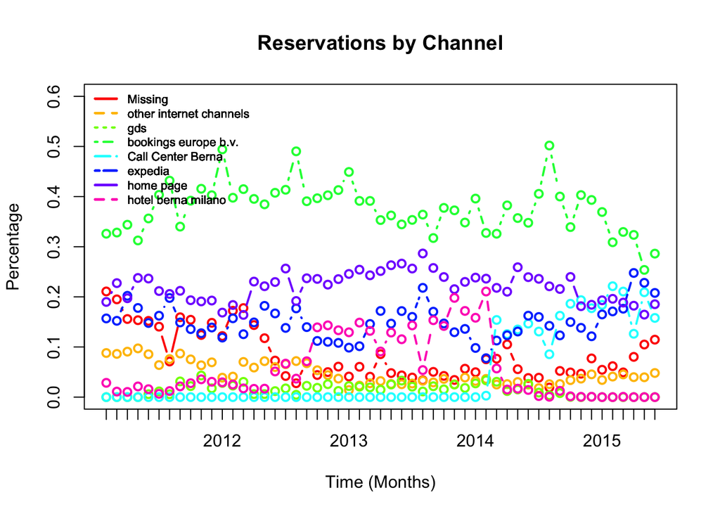

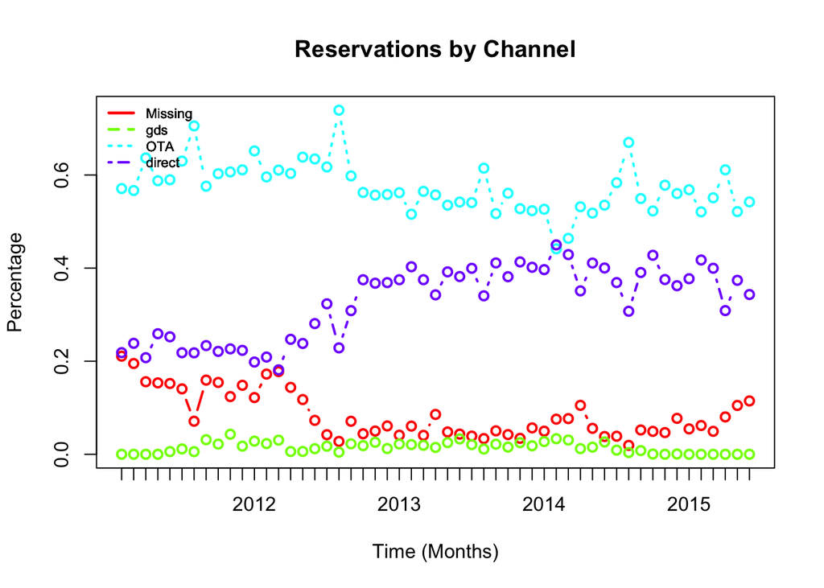